# Special Issue Markdown

# STUDY 1A

## Read in data

## First factor: Subfield

```
## # A tibble: 4 × 2
##   subfield_groups     n
##   <chr>           <int>
## 1 Cognition          91
## 2 Development        65
## 3 Other              75
## 4 Social             91
```

## Second factor: Time

```
## # A tibble: 3 × 2
##   time_period       n
##   <chr>         <int>
## 1 1st half 2014   183
## 2 1st half 2015    67
## 3 2nd half 2014    72
```

## DATA ANOVA Analysis

(#tab:unnamed-chunk-6)

*Between-subjects ANOVA for Open Data Scores*

| Effect | $F$ | $\mathit{df}_1$ | $\mathit{df}_2$ | $\mathit{MSE}$ | $p$ | $\hat{\eta}^2_G$ |
| --- | --- | --- | --- | --- | --- | --- |
| Time period | 11.29 | 2 | 310 | 41.51 | < .001 | .068 |
| Subfield groups | 2.23 | 3 | 310 | 41.51 | .085 | .021 |
| Time period $\times$ Subfield groups | 1.57 | 6 | 310 | 41.51 | .157 | .029 |

Our two-way between-subjects ANOVA generated a significant main effect of time period, $F(2, 310) = 11.29$, $\mathit{MSE} = 41.51$, $p < .001$, $\hat{\eta}^2_G = .068$. However, the main effect of subfield, $F(3, 310) = 2.23$, $\mathit{MSE} = 41.51$, $p = .085$, $\hat{\eta}^2_G = .021$, and the interaction between time period and subfield, $F(6, 310) = 1.57$, $\mathit{MSE} = 41.51$, $p = .157$, $\hat{\eta}^2_G = .029$, were not statistically significant.

## MATERIALS ANOVA Analysis

(#tab:unnamed-chunk-7)

*Between-subjects ANOVA for Open Materials Scores*

| Effect | $F$ | $\mathit{df}_1$ | $\mathit{df}_2$ | $\mathit{MSE}$ | $p$ | $\hat{\eta}^2_G$ |
| --- | --- | --- | --- | --- | --- | --- |
| Time period | 4.74 | 2 | 310 | 32.16 | .009 | .030 |
| Subfield groups | 4.03 | 3 | 310 | 32.16 | .008 | .038 |
| Time period $\times$ Subfield groups | 0.85 | 6 | 310 | 32.16 | .530 | .016 |

Our two-way between-subjects ANOVA generated a significant main effect of subfield, $F(3, 310) = 4.03$, $\mathit{MSE} = 32.16$, $p = .008$, $\hat{\eta}^2_G = .038$, and a significant main effect of time period, $F(2, 310) = 4.74$, $\mathit{MSE} = 32.16$, $p = .009$, $\hat{\eta}^2_G = .030$. However the interaction between time period and subfield, $F(6, 310) = 0.85$, $\mathit{MSE} = 32.16$, $p = .530$, $\hat{\eta}^2_G = .016$, was not statistically significant.

## PLOTS

### DATA

#### Subfield x Data Score

```
## # A tibble: 4 × 5
##   subfield_groups mean_data_score    SD     N stderr
##   <fct>                     <dbl> <dbl> <int>  <dbl>
## 1 Development                2.38  6.02    65  0.746
## 2 Social                     4.62  7.34    91  0.770
## 3 Cognition                  4.03  7.07    91  0.742
## 4 Other                      2.79  5.84    75  0.674
```

#### Time Period x Data Score

```
## # A tibble: 3 × 5
##   time_period   mean_data_score    SD     N stderr
##   <fct>                   <dbl> <dbl> <int>  <dbl>
## 1 1st half 2014            2.14  5.24   183  0.388
## 2 2nd half 2014            4.90  7.47    72  0.880
## 3 1st half 2015            6.06  8.32    67  1.02
```

#### Interaction between time and subfield - Data scores

```
## # A tibble: 12 × 6
## # Groups:   subfield_groups [4]
##    subfield_groups time_period   mean_data_score    SD     N stderr
##    <fct>           <fct>                   <dbl> <dbl> <int>  <dbl>
##  1 Development     1st half 2014           2.15   5.73    34  0.982
##  2 Development     2nd half 2014           3.31   6.78    16  1.69
##  3 Development     1st half 2015           1.93   6.13    15  1.58
##  4 Social          1st half 2014           2.27   4.69    52  0.650
##  5 Social          2nd half 2014           7.7    8.93    20  2.00
##  6 Social          1st half 2015           7.79   9.27    19  2.13
##  7 Cognition       1st half 2014           3.02   6.65    53  0.914
##  8 Cognition       2nd half 2014           4.11   6.60    19  1.51
##  9 Cognition       1st half 2015           6.79   8.23    19  1.89
## 10 Other           1st half 2014           0.932  3.03    44  0.457
## 11 Other           2nd half 2014           4      6.85    17  1.66
## 12 Other           1st half 2015           7.14   8.48    14  2.27
```

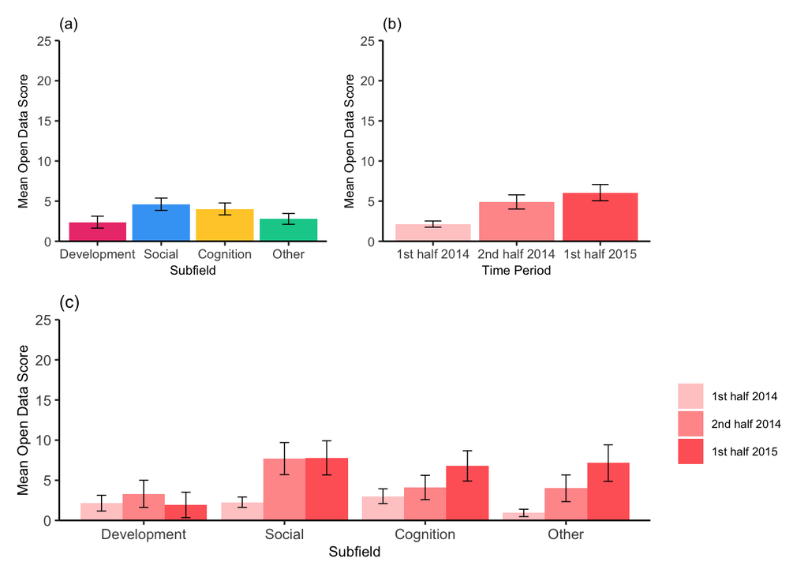

### MATERIALS

#### Subfield x Materials Score

[output not shown]

#### Time Period x Materials Score

```
## # A tibble: 3 × 5
##   time_period   mean_materials_score    SD     N stderr
##   <fct>                        <dbl> <dbl> <int>  <dbl>
## 1 1st half 2014                 2.73  5.04   183  0.373
## 2 2nd half 2014                 4.10  6.51    72  0.767
## 3 1st half 2015                 5     6.62    67  0.809
```

#### Interaction between time and subfield - Materials Score

```
## # A tibble: 12 × 6
## # Groups:   subfield_groups [4]
##    subfield_groups time_period   mean_materials_score    SD     N stderr
##    <fct>           <fct>                        <dbl> <dbl> <int>  <dbl>
##  1 Development     1st half 2014                 1.44  4.31    34  0.740
##  2 Development     2nd half 2014                 1.38  3.91    16  0.978
##  3 Development     1st half 2015                 3.13  5.89    15  1.52
##  4 Social          1st half 2014                 2.77  4.63    52  0.643
##  5 Social          2nd half 2014                 6.9   8.00    20  1.79
##  6 Social          1st half 2015                 5.21  6.81    19  1.56
##  7 Cognition       1st half 2014                 3.94  5.97    53  0.820
##  8 Cognition       2nd half 2014                 4.26  5.96    19  1.37
##  9 Cognition       1st half 2015                 6.74  6.94    19  1.59
## 10 Other           1st half 2014                 2.20  4.61    44  0.695
## 11 Other           2nd half 2014                 3.18  6.28    17  1.52
## 12 Other           1st half 2015                 4.36  6.72    14  1.80
```

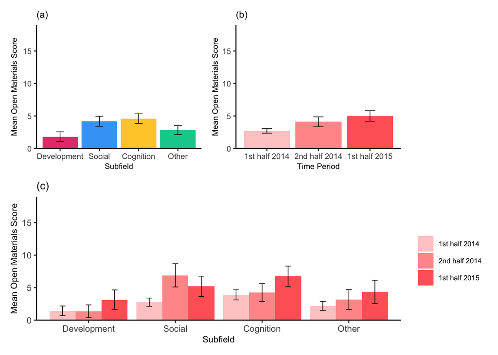

## SUBFIELD T-TESTS

### DATA

Subfield main effect for Open Data Scores was not significant, so no t-tests to run here

### MATERIALS

#### Developmental vs. Cognition

```
## Effect sizes were labelled following Cohen's (1988) recommendations.
##
## The Welch Two Sample t-test testing the difference of open_materials_score by subfield_groups (mean in group Development = 1.82, mean in group Cognition = 4.59) suggests that the effect is positive, statistically significant, and medium (difference = 2.78, 95% CI [-4.49, -1.06], t(153.74) = -3.20…
```

#### Developmental vs. Social

```
## Effect sizes were labelled following Cohen's (1988) recommendations.
##
## The Welch Two Sample t-test testing the difference of open_materials_score by subfield_groups (mean in group Development = 1.82, mean in group Social = 4.19) suggests that the effect is positive, statistically significant, and small (difference = 2.37, 95% CI [-4.08, -0.67], t(153.62) = -2.75, p …
```

#### Developmental vs. Other

```
## Effect sizes were labelled following Cohen's (1988) recommendations.
##
## The Welch Two Sample t-test testing the difference of open_materials_score by subfield_groups (mean in group Development = 1.82, mean in group Other = 2.83) suggests that the effect is positive, statistically not significant, and small (difference = 1.01, 95% CI [-2.69, 0.67], t(137.95) = -1.19, …
```

## TIME T-TESTS

### DATA

#### First half 2014 vs. Second half 2014

```
## Effect sizes were labelled following Cohen's (1988) recommendations.
##
## The Welch Two Sample t-test testing the difference of open_data_score by time_period (mean in group 1st half 2014 = 2.14, mean in group 2nd half 2014 = 4.90) suggests that the effect is positive, statistically significant, and medium (difference = 2.76, 95% CI [-4.67, -0.85], t(99.74) = -2.87, p …
```

#### Second half 2014 vs. First half 2015

```
## Effect sizes were labelled following Cohen's (1988) recommendations.
##
## The Welch Two Sample t-test testing the difference of open_data_score by time_period (mean in group 2nd half 2014 = 4.90, mean in group 1st half 2015 = 6.06) suggests that the effect is positive, statistically not significant, and very small (difference = 1.16, 95% CI [-3.82, 1.50], t(132.74) = -…
```

### MATERIALS

#### First half 2014 vs. Second half 2014

```
## Effect sizes were labelled following Cohen's (1988) recommendations.
##
## The Welch Two Sample t-test testing the difference of open_materials_score by time_period (mean in group 1st half 2014 = 2.73, mean in group 2nd half 2014 = 4.10) suggests that the effect is positive, statistically not significant, and small (difference = 1.37, 95% CI [-3.06, 0.32], t(106.17) = -…
```

#### Second half 2014 vs. First half 2015

```
## Effect sizes were labelled following Cohen's (1988) recommendations.
##
## The Welch Two Sample t-test testing the difference of open_materials_score by time_period (mean in group 2nd half 2014 = 4.10, mean in group 1st half 2015 = 5.00) suggests that the effect is positive, statistically not significant, and very small (difference = 0.90, 95% CI [-3.11, 1.30], t(135.91…
```

#### First half 2014 vs. First half 2015

```
## Effect sizes were labelled following Cohen's (1988) recommendations.
##
## The Welch Two Sample t-test testing the difference of open_materials_score by time_period (mean in group 1st half 2014 = 2.73, mean in group 1st half 2015 = 5.00) suggests that the effect is positive, statistically significant, and medium (difference = 2.27, 95% CI [-4.04, -0.51], t(95.44) = -2.5…
```

# STUDY 1B CONFIRMATORY - 2019-20

## Read in data

## First factor: Subfield

```
## # A tibble: 4 × 2
##   subfield_groups     n
##   <chr>           <int>
## 1 Cognition          61
## 2 Development        34
## 3 Other              41
## 4 Social             57
```

## Second factor: Time

```
## # A tibble: 3 × 2
##   time_period       n
##   <chr>         <int>
## 1 1st half 2020    91
## 2 2nd half 2019    65
## 3 2nd half 2020    37
```

```
##  subfield_groups 1st half 2020 2nd half 2019 2nd half 2020
##        Cognition            29            19            13
##      Development            12            13             9
##            Other            17            17             7
##           Social            33            16             8
```

## DATA ANOVA Analysis

(#tab:unnamed-chunk-26)

*Between-subjects ANOVA for Open Data Scores*

| Effect | $F$ | $\mathit{df}_1$ | $\mathit{df}_2$ | $\mathit{MSE}$ | $p$ | $\hat{\eta}^2_G$ |
| --- | --- | --- | --- | --- | --- | --- |
| Time period | 3.68 | 2 | 181 | 70.92 | .027 | .039 |
| Subfield groups | 3.31 | 3 | 181 | 70.92 | .021 | .052 |
| Time period $\times$ Subfield groups | 1.11 | 6 | 181 | 70.92 | .358 | .035 |

Our two-way between-subjects ANOVA generated a significant main effect of time period, $F(2, 181) = 3.68$, $\mathit{MSE} = 70.92$, $p = .027$, $\hat{\eta}^2_G = .039$, and a significant main effect of subfield, $F(3, 181) = 3.31$, $\mathit{MSE} = 70.92$, $p = .021$, $\hat{\eta}^2_G = .052$. However, the interaction between time period and subfield, $F(6, 181) = 1.11$, $\mathit{MSE} = 70.92$, $p = .358$, $\hat{\eta}^2_G = .035$, was not statistically significant.

## MATERIALS ANOVA Analysis

```
## Contrasts set to contr.sum for the following variables: time_period, subfield_groups
```

(#tab:unnamed-chunk-27)

*Between-subjects ANOVA for Open Materials Scores*

| Effect | $F$ | $\mathit{df}_1$ | $\mathit{df}_2$ | $\mathit{MSE}$ | $p$ | $\hat{\eta}^2_G$ |
| --- | --- | --- | --- | --- | --- | --- |
| Time period | 0.37 | 2 | 181 | 53.87 | .694 | .004 |
| Subfield groups | 5.24 | 3 | 181 | 53.87 | .002 | .080 |
| Time period $\times$ Subfield groups | 0.48 | 6 | 181 | 53.87 | .822 | .016 |

Our two-way between-subjects ANOVA generated a significant main effect of subfield, $F(3, 181) = 5.24$, $\mathit{MSE} = 53.87$, $p = .002$, $\hat{\eta}^2_G = .080$, however the main effect of time period, $F(2, 181) = 0.37$, $\mathit{MSE} = 53.87$, $p = .694$, $\hat{\eta}^2_G = .004$, and the interaction between time period and subfield, $F(6, 181) = 0.48$, $\mathit{MSE} = 53.87$, $p = .822$, $\hat{\eta}^2_G = .016$, were not statistically significant.

## PLOTS

### DATA

#### Subfield x Data Score

```
## # A tibble: 4 × 5
##   subfield_groups mean_data_score    SD     N stderr
##   <fct>                     <dbl> <dbl> <int>  <dbl>
## 1 Development                12.5  8.83    34  1.51
## 2 Social                     13.3  9.17    57  1.21
## 3 Cognition                  17.2  7.37    61  0.944
## 4 Other                      13.1  9.07    41  1.42
```

#### Time Period x Data Score

```
## # A tibble: 3 × 5
##   time_period   mean_data_score    SD     N stderr
##   <fct>                   <dbl> <dbl> <int>  <dbl>
## 1 2nd half 2019            12.1  9.19    65  1.14
## 2 1st half 2020            16.0  8.08    91  0.847
## 3 2nd half 2020            14.4  8.70    37  1.43
```

#### Interaction between time and subfield - Data scores

```
## # A tibble: 12 × 6
## # Groups:   subfield_groups [4]
##    subfield_groups time_period   mean_data_score    SD     N stderr
##    <fct>           <fct>                   <dbl> <dbl> <int>  <dbl>
##  1 Development     2nd half 2019            9.85  9.30    13   2.58
##  2 Development     1st half 2020           16.1   7.28    12   2.10
##  3 Development     2nd half 2020           11.6   9.33     9   3.11
##  4 Social          2nd half 2019            9.88  9.59    16   2.40
##  5 Social          1st half 2020           15.4   8.90    33   1.55
##  6 Social          2nd half 2020           11.6   7.93     8   2.80
##  7 Cognition       2nd half 2019           16.8   6.86    19   1.57
##  8 Cognition       1st half 2020           16.4   7.99    29   1.48
##  9 Cognition       2nd half 2020           19.6   6.63    13   1.84
## 10 Other           2nd half 2019           10.8   9.82    17   2.38
## 11 Other           1st half 2020           16.3   7.73    17   1.87
## 12 Other           2nd half 2020           11.3   9.16     7   3.46
```

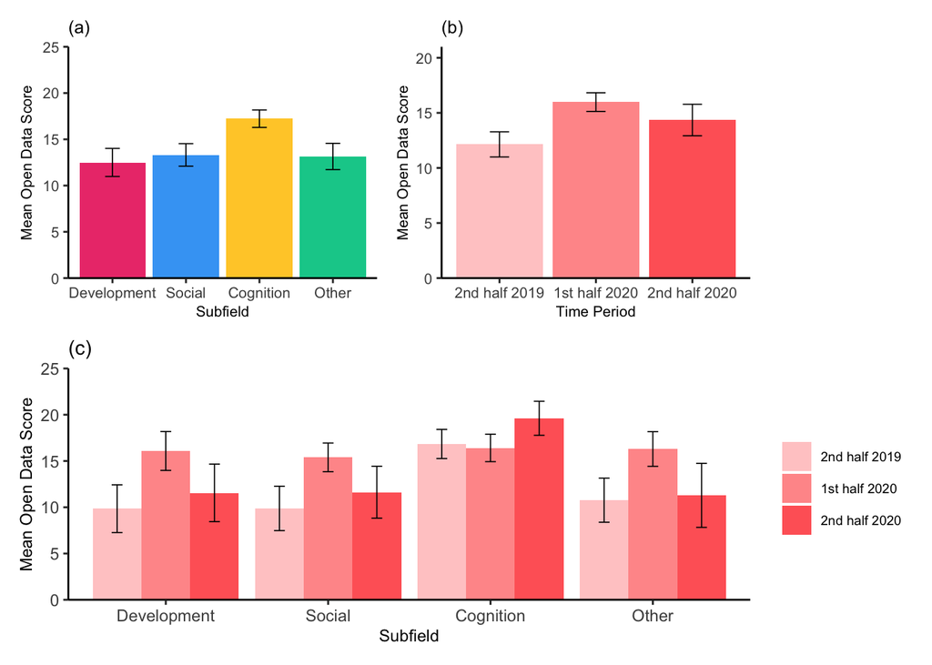

### MATERIALS

#### Subfield x Materials Score

[output not shown]

### Time Period x Materials Score

```
## # A tibble: 3 × 5
##   time_period   mean_materials_score    SD     N stderr
##   <fct>                        <dbl> <dbl> <int>  <dbl>
## 1 2nd half 2019                 8.35  7.53    65  0.934
## 2 1st half 2020                 9.54  7.31    91  0.766
## 3 2nd half 2020                 9.46  8.03    37  1.32
```

### Interaction between time and subfield - Materials Score

```
## # A tibble: 12 × 6
## # Groups:   subfield_groups [4]
##    subfield_groups time_period   mean_materials_score    SD     N stderr
##    <fct>           <fct>                        <dbl> <dbl> <int>  <dbl>
##  1 Development     2nd half 2019                 6.92  7.52    13   2.09
##  2 Development     1st half 2020                 6.33  7.62    12   2.20
##  3 Development     2nd half 2020                 7.22  8.47     9   2.82
##  4 Social          2nd half 2019                 6.69  7.58    16   1.89
##  5 Social          1st half 2020                 9.06  7.28    33   1.27
##  6 Social          2nd half 2020                 7.38  8.11     8   2.87
##  7 Cognition       2nd half 2019                12.3   6.50    19   1.49
##  8 Cognition       1st half 2020                11.4   6.92    29   1.28
##  9 Cognition       2nd half 2020                13.6   6.63    13   1.84
## 10 Other           2nd half 2019                 6.59  7.53    17   1.83
## 11 Other           1st half 2020                 9.53  7.49    17   1.82
## 12 Other           2nd half 2020                 7     8.29     7   3.13
```

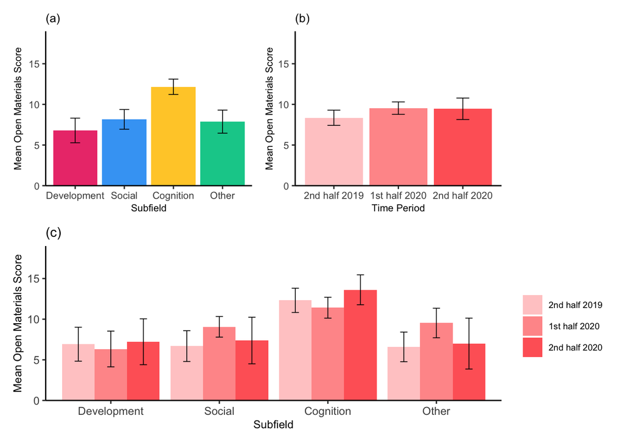

## SUBFIELD T-TESTS

### DATA

#### Development vs. Cognition

```
## Effect sizes were labelled following Cohen's (1988) recommendations.
##
## The Welch Two Sample t-test testing the difference of open_data_score by subfield_groups (mean in group Development = 12.50, mean in group Cognition = 17.23) suggests that the effect is positive, statistically significant, and medium (difference = 4.73, 95% CI [-8.30, -1.16], t(58.75) = -2.65, p …
```

#### Development vs. Social

```
## Effect sizes were labelled following Cohen's (1988) recommendations.
##
## The Welch Two Sample t-test testing the difference of open_data_score by subfield_groups (mean in group Development = 12.50, mean in group Social = 13.32) suggests that the effect is positive, statistically not significant, and very small (difference = 0.82, 95% CI [-4.68, 3.05], t(71.68) = -0.42…
```

#### Development vs. Other

```
## Effect sizes were labelled following Cohen's (1988) recommendations.
##
## The Welch Two Sample t-test testing the difference of open_data_score by subfield_groups (mean in group Development = 12.50, mean in group Other = 13.15) suggests that the effect is positive, statistically not significant, and very small (difference = 0.65, 95% CI [-4.78, 3.49], t(71.12) = -0.31,…
```

### MATERIAL

#### Developmental vs. Cognition

```
## Effect sizes were labelled following Cohen's (1988) recommendations.
##
## The Welch Two Sample t-test testing the difference of open_materials_score by subfield_groups (mean in group Development = 6.79, mean in group Cognition = 12.16) suggests that the effect is positive, statistically significant, and large (difference = 5.37, 95% CI [-8.48, -2.26], t(61.36) = -3.45,…
```

#### Developmental vs. Social

```
## Effect sizes were labelled following Cohen's (1988) recommendations.
##
## The Welch Two Sample t-test testing the difference of open_materials_score by subfield_groups (mean in group Development = 6.79, mean in group Social = 8.16) suggests that the effect is positive, statistically not significant, and small (difference = 1.36, 95% CI [-4.62, 1.89], t(68.36) = -0.84, …
```

### Developmental vs. Other

```
## Effect sizes were labelled following Cohen's (1988) recommendations.
##
## The Welch Two Sample t-test testing the difference of open_materials_score by subfield_groups (mean in group Development = 6.79, mean in group Other = 7.88) suggests that the effect is positive, statistically not significant, and very small (difference = 1.08, 95% CI [-4.59, 2.42], t(70.45) = -0.…
```

## TIME T-TESTS

### DATA

#### Second half 2019 vs. First half 2020

```
## Effect sizes were labelled following Cohen's (1988) recommendations.
##
## The Welch Two Sample t-test testing the difference of open_data_score by time_period (mean in group 2nd half 2019 = 12.14, mean in group 1st half 2020 = 15.98) suggests that the effect is positive, statistically significant, and small (difference = 3.84, 95% CI [-6.65, -1.03], t(126.73) = -2.70, …
```

#### First half 2020 vs. Second half 2020

```
## Effect sizes were labelled following Cohen's (1988) recommendations.
##
## The Welch Two Sample t-test testing the difference of open_data_score by time_period (mean in group 1st half 2020 = 15.98, mean in group 2nd half 2020 = 14.35) suggests that the effect is negative, statistically not significant, and small (difference = -1.63, 95% CI [-1.69, 4.95], t(62.65) = 0.98…
```

### MATERIALS

There time period main effect for Open Materials Scores was not statistically significant, so no t-tests to run here

# STUDY 1B CONFIRMATORY - 2014-15 vs. 2019-20

## Merge 1A and 1B data into one dataframe

## Condense to two levels of time

```
## # A tibble: 4 × 2
##   subfield_groups     n
##   <fct>           <int>
## 1 Development        99
## 2 Social            148
## 3 Cognition         152
## 4 Other             116
```

```
## # A tibble: 2 × 2
##   time_period     n
##   <fct>       <int>
## 1 2014-15       322
## 2 2019-20       193
```

## DATA ANOVA

(#tab:unnamed-chunk-44)

*Between-subjects ANOVA for Open Data Scores*

| Effect | $F$ | $\mathit{df}_1$ | $\mathit{df}_2$ | $\mathit{MSE}$ | $p$ | $\hat{\eta}^2_G$ |
| --- | --- | --- | --- | --- | --- | --- |
| Time period | 248.98 | 1 | 507 | 55.28 | < .001 | .329 |
| Subfield groups | 3.74 | 3 | 507 | 55.28 | .011 | .022 |
| Time period $\times$ Subfield groups | 2.28 | 3 | 507 | 55.28 | .078 | .013 |

Our two-way between-subjects ANOVA generated a significant main effect of time period, $F(1, 507) = 248.98$, $\mathit{MSE} = 55.28$, $p < .001$, $\hat{\eta}^2_G = .329$, and a significant main effect of subfield, $F(3, 507) = 3.74$, $\mathit{MSE} = 55.28$, $p = .011$, $\hat{\eta}^2_G = .022$. However, the interaction between time period and subfield, $F(3, 507) = 2.28$, $\mathit{MSE} = 55.28$, $p = .078$, $\hat{\eta}^2_G = .013$, was not statistically significant.

## MATERIALS ANOVA Analysis

(#tab:unnamed-chunk-45)

*Between-subjects ANOVA for Open Materials Scores*

| Effect | $F$ | $\mathit{df}_1$ | $\mathit{df}_2$ | $\mathit{MSE}$ | $p$ | $\hat{\eta}^2_G$ |
| --- | --- | --- | --- | --- | --- | --- |
| Time period | 90.18 | 1 | 507 | 40.21 | < .001 | .151 |
| Subfield groups | 8.17 | 3 | 507 | 40.21 | < .001 | .046 |
| Time period $\times$ Subfield groups | 2.07 | 3 | 507 | 40.21 | .103 | .012 |

Our two-way between-subjects ANOVA generated a significant main effect of subfield, $F(3, 507) = 8.17$, $\mathit{MSE} = 40.21$, $p < .001$, $\hat{\eta}^2_G = .046$, and time period, $F(1, 507) = 90.18$, $\mathit{MSE} = 40.21$, $p < .001$, $\hat{\eta}^2_G = .151$. However, the interaction between time period and subfield, $F(3, 507) = 2.07$, $\mathit{MSE} = 40.21$, $p = .103$, $\hat{\eta}^2_G = .012$, was not statistically significant.

## PLOTS

### DATA

#### Subfield x Data Score

```
## # A tibble: 4 × 5
##   subfield_groups mean_data_score    SD     N stderr
##   <fct>                     <dbl> <dbl> <int>  <dbl>
## 1 Development                5.86  8.55    99  0.860
## 2 Social                     7.97  9.12   148  0.749
## 3 Cognition                  9.33  9.67   152  0.784
## 4 Other                      6.45  8.68   116  0.806
```

#### Time Period x Data Score

```
## # A tibble: 2 × 5
##   time_period mean_data_score    SD     N stderr
##   <fct>                 <dbl> <dbl> <int>  <dbl>
## 1 2014-15                3.57  6.71   322  0.374
## 2 2019-20               14.4   8.71   193  0.627
```

#### Interaction between time and subfield - Data scores

```
## # A tibble: 8 × 6
## # Groups:   subfield_groups [4]
##   subfield_groups time_period mean_data_score    SD     N stderr
##   <fct>           <fct>                 <dbl> <dbl> <int>  <dbl>
## 1 Development     2014-15                2.38  6.02    65  0.746
## 2 Development     2019-20               12.5   8.83    34  1.51
## 3 Social          2014-15                4.62  7.34    91  0.770
## 4 Social          2019-20               13.3   9.17    57  1.21
## 5 Cognition       2014-15                4.03  7.07    91  0.742
## 6 Cognition       2019-20               17.2   7.37    61  0.944
## 7 Other           2014-15                2.79  5.84    75  0.674
## 8 Other           2019-20               13.1   9.07    41  1.42
```

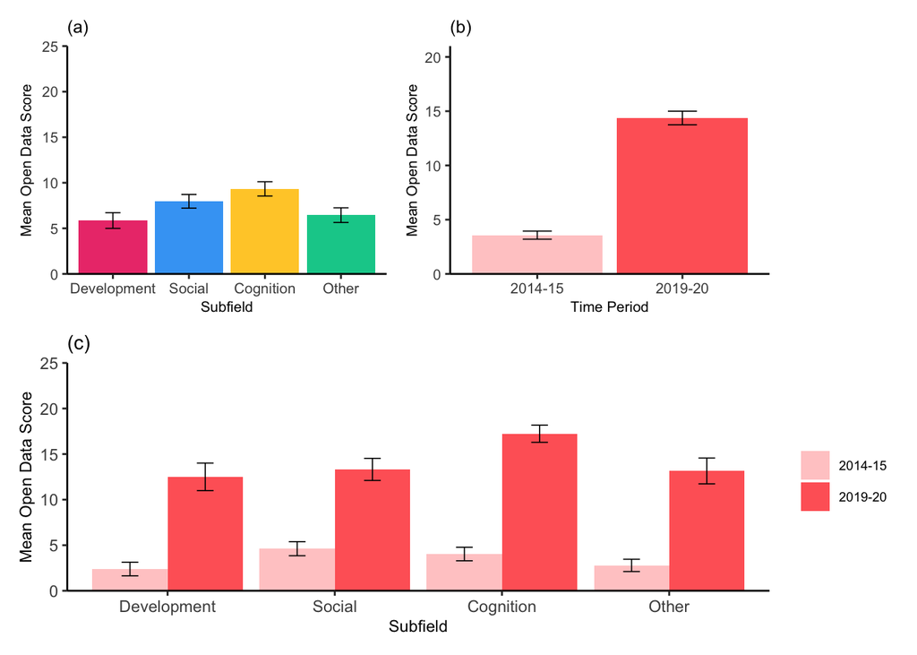

### MATERIALS

#### Subfield x Materials Score

```
## # A tibble: 4 × 5
##   subfield_groups mean_materials_score    SD     N stderr
##   <fct>                          <dbl> <dbl> <int>  <dbl>
## 1 Development                     3.53  6.24    99  0.627
## 2 Social                          5.72  6.93   148  0.569
## 3 Cognition                       7.63  7.39   152  0.599
## 4 Other                           4.61  6.70   116  0.622
```

#### Time Period x Materials Score

```
## # A tibble: 2 × 5
##   time_period mean_materials_score    SD     N stderr
##   <fct>                      <dbl> <dbl> <int>  <dbl>
## 1 2014-15                     3.51  5.80   322  0.323
## 2 2019-20                     9.12  7.50   193  0.540
```

### Interaction between time and subfield - Materials Score

```
## # A tibble: 8 × 6
## # Groups:   subfield_groups [4]
##   subfield_groups time_period mean_materials_score    SD     N stderr
##   <fct>           <fct>                      <dbl> <dbl> <int>  <dbl>
## 1 Development     2014-15                     1.82  4.62    65  0.573
## 2 Development     2019-20                     6.79  7.58    34  1.30
## 3 Social          2014-15                     4.19  6.16    91  0.646
## 4 Social          2019-20                     8.16  7.42    57  0.983
## 5 Cognition       2014-15                     4.59  6.21    91  0.651
## 6 Cognition       2019-20                    12.2   6.67    61  0.854
## 7 Other           2014-15                     2.83  5.43    75  0.627
## 8 Other           2019-20                     7.88  7.58    41  1.18
```

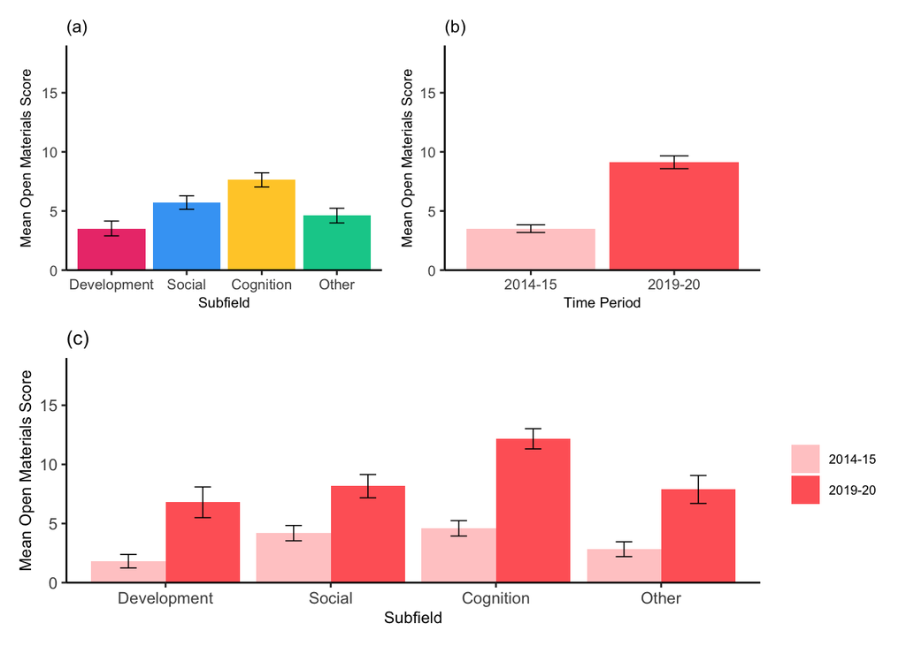

## SUBFIELD T-TESTS

### DATA

#### Development vs. Cognition

```
## Effect sizes were labelled following Cohen's (1988) recommendations.
##
## The Welch Two Sample t-test testing the difference of open_data_score by subfield_groups (mean in group Development = 5.86, mean in group Cognition = 9.33) suggests that the effect is positive, statistically significant, and small (difference = 3.47, 95% CI [-5.76, -1.18], t(226.98) = -2.98, p = …
```

#### Development vs. Social

```
## Effect sizes were labelled following Cohen's (1988) recommendations.
##
## The Welch Two Sample t-test testing the difference of open_data_score by subfield_groups (mean in group Development = 5.86, mean in group Social = 7.97) suggests that the effect is positive, statistically not significant, and small (difference = 2.11, 95% CI [-4.36, 0.14], t(219.13) = -1.85, p = …
```

#### Development vs. Other

```
## Effect sizes were labelled following Cohen's (1988) recommendations.
##
## The Welch Two Sample t-test testing the difference of open_data_score by subfield_groups (mean in group Development = 5.86, mean in group Other = 6.45) suggests that the effect is positive, statistically not significant, and very small (difference = 0.59, 95% CI [-2.91, 1.73], t(208.60) = -0.50, …
```

### MATERIAL

#### Developmental vs. Cognition

```
## Effect sizes were labelled following Cohen's (1988) recommendations.
##
## The Welch Two Sample t-test testing the difference of open_materials_score by subfield_groups (mean in group Development = 3.53, mean in group Cognition = 7.63) suggests that the effect is positive, statistically significant, and medium (difference = 4.11, 95% CI [-5.81, -2.40], t(232.75) = -4.74…
```

#### Developmental vs. Social

```
## Effect sizes were labelled following Cohen's (1988) recommendations.
##
## The Welch Two Sample t-test testing the difference of open_materials_score by subfield_groups (mean in group Development = 3.53, mean in group Social = 5.72) suggests that the effect is positive, statistically significant, and small (difference = 2.19, 95% CI [-3.86, -0.52], t(224.53) = -2.59, p …
```

#### Developmental vs. Other

```
## Effect sizes were labelled following Cohen's (1988) recommendations.
##
## The Welch Two Sample t-test testing the difference of open_materials_score by subfield_groups (mean in group Development = 3.53, mean in group Other = 4.61) suggests that the effect is positive, statistically not significant, and very small (difference = 1.09, 95% CI [-2.83, 0.65], t(211.35) = -1…
```

# STUDY 1B EXPLORATORY

## RAINCLOUD PLOTS

### 1A Data Plot

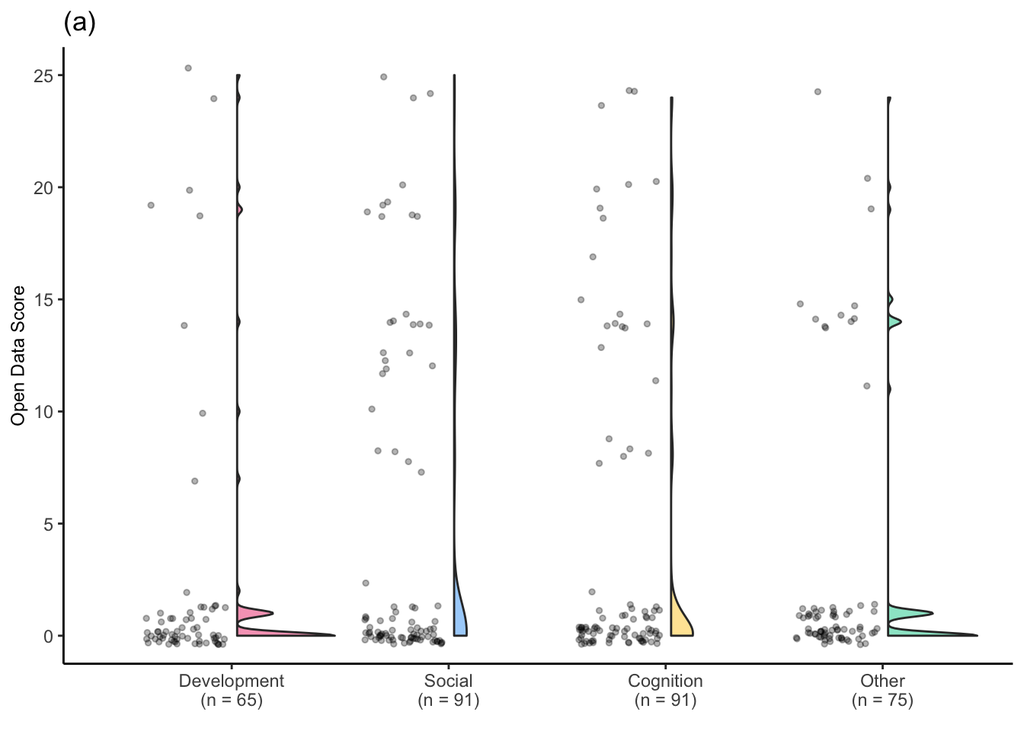

### 1A Materials Plot

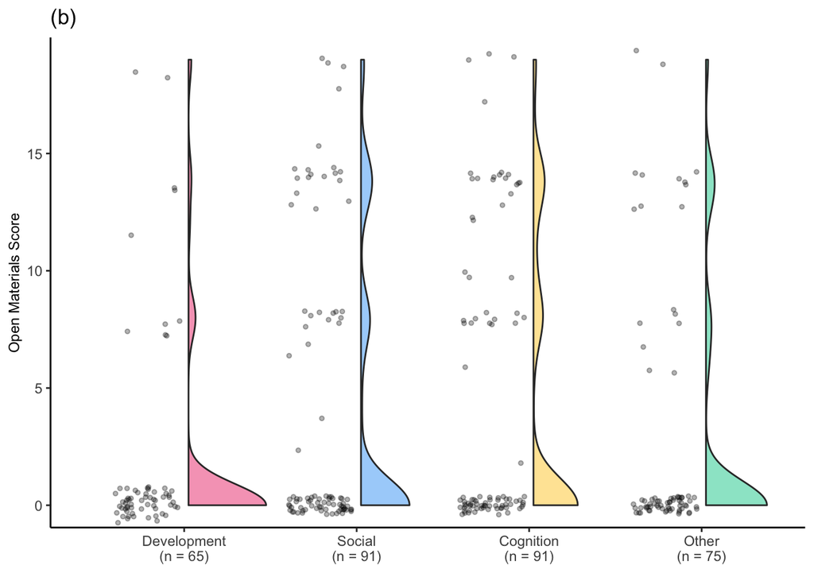

### 1B Data Plot

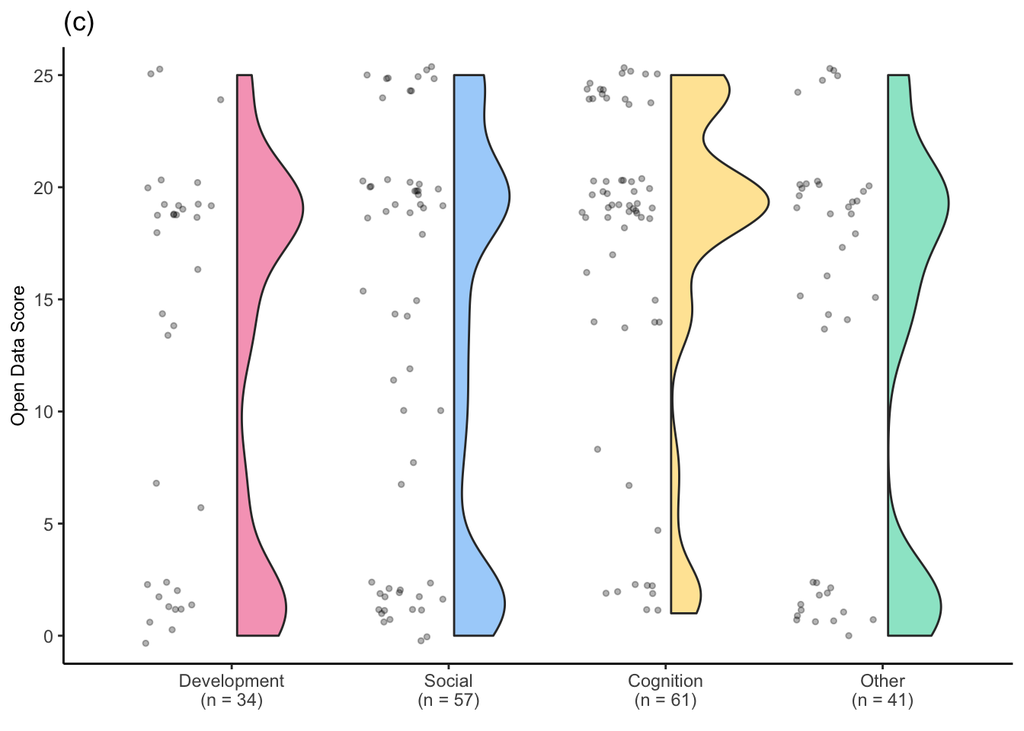

### 1B Materials Plot

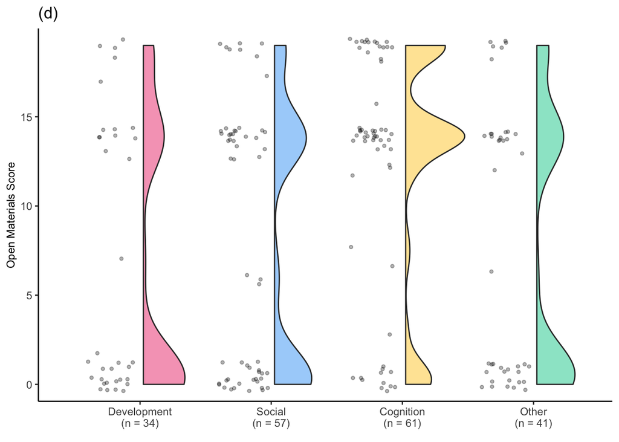

### Figure

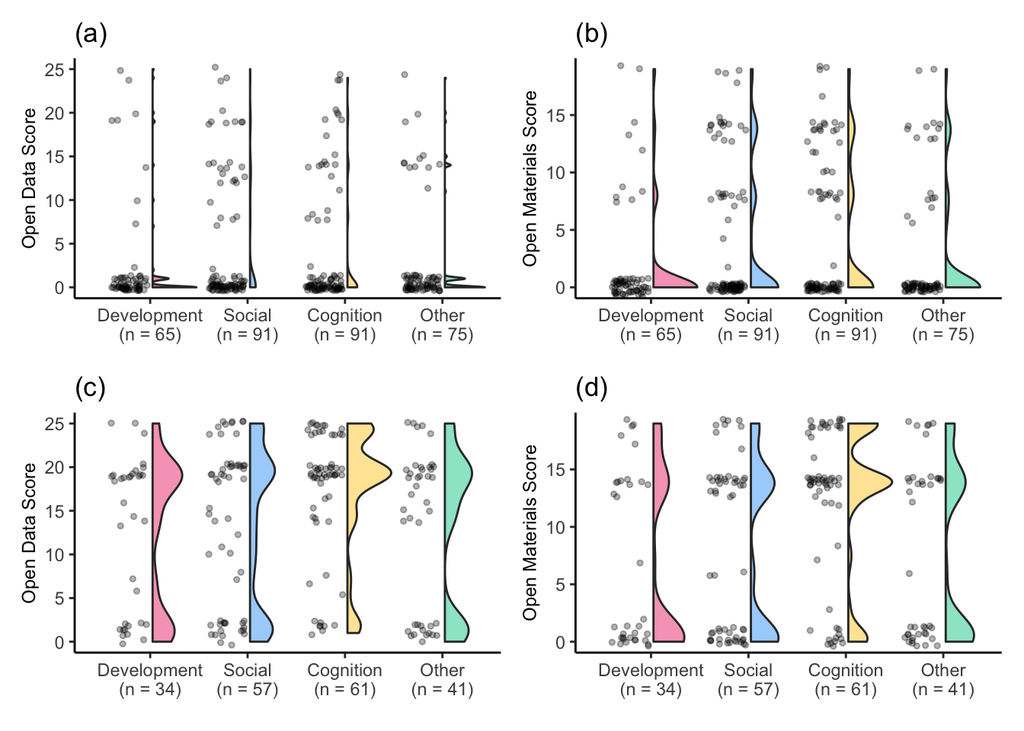

## OPEN SCIENCE BADGES

### Open Data Badge Plot

#### Select only relevant 1A variables

#### Summary tables

#### Bind all statistics together

#### Select only relevant 1B variables

#### Summary tables

#### Bind all statistics together

#### Combine 1A and 1B stats together

#### Plot combined data

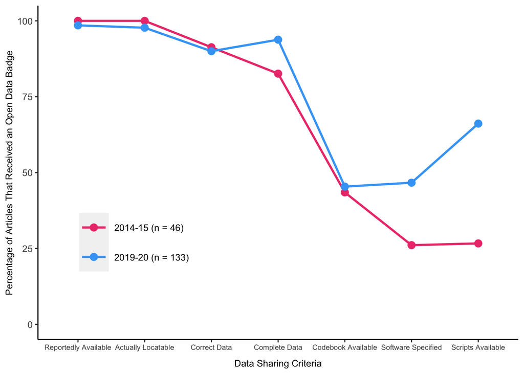

### Open Materials Badge Plot

#### Select only relevant 1A variables

#### Summary tables

#### Bind all statistics

#### Select only relevant 1Bvariables

#### Summary tables

#### Bind all statistics

#### Combine 1A and 1B stats together

#### Plot combined data

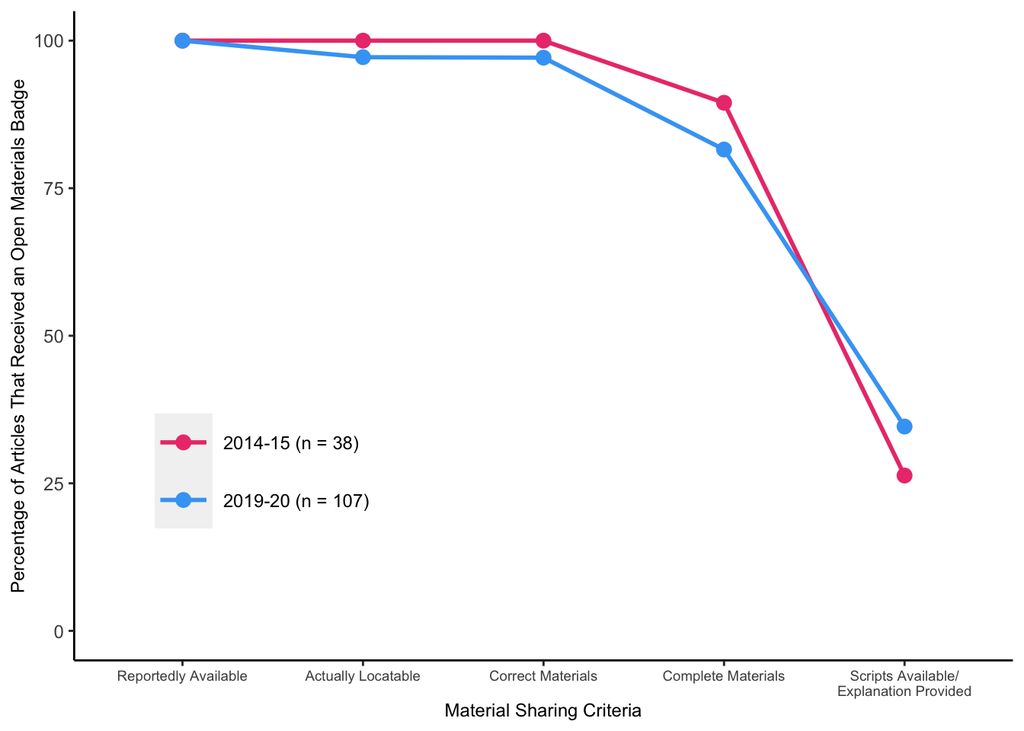